# Coursera Final Project

#### Title: Practical Machine Learning Project - Quantified Self Movement Data Analysis Report

#### Author: Pierre Roux-Lafargue

## Background

##### Using devices such as Jawbone Up, Nike FuelBand, and Fitbit it is now possible to collect a large amount of data about personal activity relatively inexpensively. These type of devices are part of the quantified self movement – a group of enthusiasts who take measurements about themselves regularly to improve their health, to find patterns in their behavior, or because they are tech geeks. One thing that people regularly do is quantify how much of a particular activity they do, but they rarely quantify how well they do it.

##### The goal of this project is to use data from accelerometers on the belt, forearm, arm, and dumbell of 6 participants to create a machine learning algorythm to measure how well the exercises were performed. The participants were asked to perform barbell lifts correctly and incorrectly in 5 different ways.

##### More information is available from the website here: #####http://web.archive.org/web/20161224072740/http:/groupware.les.inf.puc-rio.br/har (see the section on the Weight Lifting Exercise Dataset).

## Model Discussion

#### Boosting

##### For our application we will use the Gradient Boosting Machine (gbm) package. This method uses decision trees as classifier and aggregates them in order to optimize prediction. In the package the important things to consider are 1) n.trees, 2) interaction.depth and 3) shrinkage. While all these values could be tuned differently, the caret package optimizes them. We therefore left the default values. We also cross validated our model 5 times, like in the random forest model, in order to improve out of sample error predictably of our model. From the caret package the optimized values lead to the construction of gbm model which had a total of 150 trees, each tree had a depth of 3 and the shrinkage = 0.1. These tuning parameters resulted in an out of sample accuracy measure of 98.78% which is better than the classification tree but slightly worse than the random forest model.

## Conclusion

##### The accuracy measure (true positives and true negatives divided by the number of true positives, true negatives, false positives, and false negatives) of the models were (in increasing order): 1) classification tree algorithm (57.28%) 2) boosting machine algorithm (98.78%) and 3) random forest algorithm (99.78%). As such, the out of sample errors are equal to 42.72%, 1.22% and 0.22% respectively. The best model was therfore the random forest algorithm. Its prediction on the testing set of the classe variable can be found at the end of the document.

## Code

```r
# Loading the required packages
library(caret)
```

```r
library(rpart)
library(corrplot)
library(httr)
library(RCurl)
library(rattle)
# Getting the data
testing <- read.csv("https://raw.githubusercontent.com/pierrerl-py/Practical-Machine-Learning---Johns-Hopkins-University/master/pml-testing.csv")
training <- read.csv("https://raw.githubusercontent.com/pierrerl-py/Practical-Machine-Learning---Johns-Hopkins-University/master/pml-training.csv")
```

### Cleaning up the data.

```r
# Removing predictors which are not useful (either have near 0 variance or are N/A or have little predictive power).
NZV <- nearZeroVar(training, saveMetrics = TRUE)
training <- training[, !NZV$nzv]
testing <- testing[, !NZV$nzv]
rm(NZV)

keep_not_NA <- (colSums(is.na(training)) == 0)
training <- training[, keep_not_NA]
testing <- testing[, keep_not_NA]
rm(keep_not_NA)

regex <- grepl("^X|timestamp|user_name", names(training))
training <- training[, !regex]
testing <- testing[, !regex]
rm(regex)
dim(training)
```

```
## [1] 19622    54
```

### Partitionaing the training data to have a validation set.

```r
set.seed(4321) # to replicate.

inTrain <- createDataPartition(training$classe,
                              p = 0.70,
                              list = FALSE)

validation <- training[-inTrain, ]
training <- training[inTrain, ]
rm(inTrain)
```

### Modeling.

#### Classification Tree

[figure not shown]

```r
set.seed(4321)
mod_ct <- train(classe ~ ., data=training, method = "rpart")

# Ploting the model.

fancyRpartPlot(mod_ct$finalModel)
```

```r
# Testing the model.
pred_ct <- predict(mod_ct, validation)
CM_ct <- confusionMatrix(pred_ct, validation$classe) #statistics to see accuracy of model
CM_ct
```

```
## Confusion Matrix and Statistics
##
##           Reference
## Prediction    A    B    C    D    E
##          A 1495  261  167  173   39
##          B   26  388   32  173   92
##          C  149  490  827  585  290
##          D    0    0    0    0    0
##          E    4    0    0   33  661
##
## Overall Statistics
##
##                Accuracy : 0.5728
##                  95% CI : (0.5601, 0.5855)
##     No Information Rate : 0.2845
##     P-Value [Acc > NIR] : < 2.2e-16
##
##                   Kappa : 0.4539
##
##  Mcnemar's Test P-Value : < 2.2e-16
##
## Statistics by Class:
##
##                      Class: A Class: B Class: C Class: D Class: E
## Sensitivity            0.8931  0.34065   0.8060   0.0000   0.6109
## Specificity            0.8480  0.93194   0.6884   1.0000   0.9923
## Pos Pred Value         0.7002  0.54571   0.3533      NaN   0.9470
## Neg Pred Value         0.9523  0.85485   0.9438   0.8362   0.9188
## Prevalence             0.2845  0.19354   0.1743   0.1638   0.1839
## Detection Rate         0.2540  0.06593   0.1405   0.0000   0.1123
## Detection Prevalence   0.3628  0.12082   0.3978   0.0000   0.1186
## Balanced Accuracy      0.8705  0.63630   0.7472   0.5000   0.8016
```

```r
varImp(mod_ct)
```

```
## rpart variable importance
##
##   only 20 most important variables shown (out of 53)
##
##                   Overall
## pitch_forearm      100.00
## roll_forearm        90.00
## magnet_dumbbell_y   89.56
## num_window          82.86
## roll_belt           67.26
## yaw_belt            58.23
## magnet_dumbbell_z   54.44
## accel_belt_z        40.57
## magnet_belt_y       39.43
## roll_dumbbell       34.00
## total_accel_belt    33.25
## magnet_arm_x        26.87
## accel_arm_x         24.81
## pitch_belt          21.40
## magnet_dumbbell_x   18.89
## accel_dumbbell_y    15.44
## accel_forearm_y      0.00
## total_accel_arm      0.00
## pitch_dumbbell       0.00
## gyros_arm_z          0.00
```

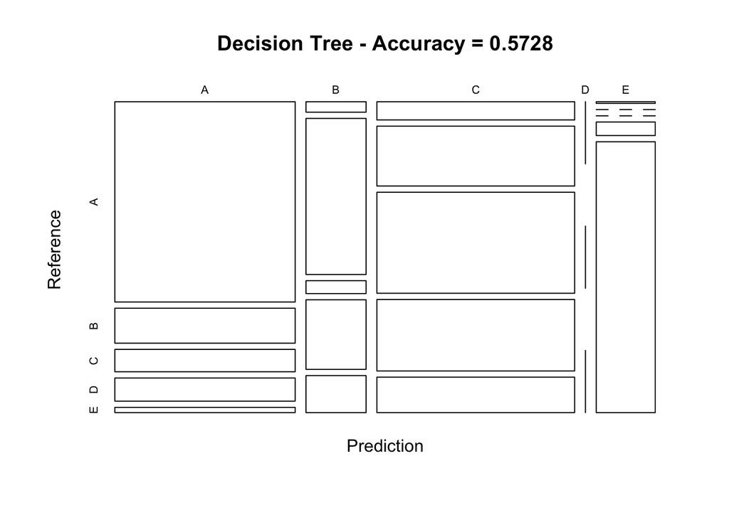

```r
# Plot the model
plot(CM_ct$table, col = CM_ct$byClass,
    main = paste("Decision Tree - Accuracy =", round(CM_ct$overall['Accuracy'], 4)))
```

#### Random Forest

```r
Control_rf = trainControl(method = "cv", 5, verboseIter = FALSE)

set.seed(4321)
mtry <- sqrt(length(names(training)))
tunegrid <- expand.grid(.mtry=mtry)
mod_rf <- train(classe~.,
                   data=training,
                   method='rf',
                   metric='Accuracy',
                   tuneGrid=tunegrid,
                   trControl=Control_rf)

mod_rf
```

```
## Random Forest
##
## 13737 samples
##    53 predictor
##     5 classes: 'A', 'B', 'C', 'D', 'E'
##
## No pre-processing
## Resampling: Cross-Validated (5 fold)
## Summary of sample sizes: 10990, 10990, 10988, 10990, 10990
## Resampling results:
##
##   Accuracy   Kappa
##   0.9959961  0.9949353
##
## Tuning parameter 'mtry' was held constant at a value of 7.348469
```

```r
mod_rf$finalModel$ntree
```

```
## [1] 500
```

```r
 # Testing the model.
pred_rf <- predict(mod_rf, validation)
CM_rf <- confusionMatrix(pred_rf, validation$classe) #statistics to see accuracy of model
CM_rf
```

```
## Confusion Matrix and Statistics
##
##           Reference
## Prediction    A    B    C    D    E
##          A 1673    2    0    0    0
##          B    1 1137    3    0    0
##          C    0    0 1023    5    0
##          D    0    0    0  958    1
##          E    0    0    0    1 1081
##
## Overall Statistics
##
##                Accuracy : 0.9978
##                  95% CI : (0.9962, 0.9988)
##     No Information Rate : 0.2845
##     P-Value [Acc > NIR] : < 2.2e-16
##
##                   Kappa : 0.9972
##
##  Mcnemar's Test P-Value : NA
##
## Statistics by Class:
##
##                      Class: A Class: B Class: C Class: D Class: E
## Sensitivity            0.9994   0.9982   0.9971   0.9938   0.9991
## Specificity            0.9995   0.9992   0.9990   0.9998   0.9998
## Pos Pred Value         0.9988   0.9965   0.9951   0.9990   0.9991
## Neg Pred Value         0.9998   0.9996   0.9994   0.9988   0.9998
## Prevalence             0.2845   0.1935   0.1743   0.1638   0.1839
## Detection Rate         0.2843   0.1932   0.1738   0.1628   0.1837
## Detection Prevalence   0.2846   0.1939   0.1747   0.1630   0.1839
## Balanced Accuracy      0.9995   0.9987   0.9980   0.9968   0.9994
```

[figure not shown]

```r
 # Ploting the model

plot(CM_rf$table, col = CM_rf$byClass,
    main = paste("Decision Tree - Accuracy =", round(CM_rf$overall['Accuracy'], 4)))
```

#### Boosting

```r
Control_gbm <- trainControl(method = "cv", 5)

set.seed(4321)
mod_gbm <- train(classe~., data = training, trControl = Control_gbm, method = "gbm", verbose = FALSE)
print(mod_gbm)
```

```
## Stochastic Gradient Boosting
##
## 13737 samples
##    53 predictor
##     5 classes: 'A', 'B', 'C', 'D', 'E'
##
## No pre-processing
## Resampling: Cross-Validated (5 fold)
## Summary of sample sizes: 10990, 10990, 10988, 10990, 10990
## Resampling results across tuning parameters:
##
##   interaction.depth  n.trees  Accuracy   Kappa
##   1                   50      0.7624691  0.6987187
##   1                  100      0.8328616  0.7884217
##   1                  150      0.8716611  0.8375987
##   2                   50      0.8868037  0.8566886
##   2                  100      0.9390695  0.9229070
##   2                  150      0.9630188  0.9532149
##   3                   50      0.9346293  0.9172594
##   3                  100      0.9716085  0.9640751
##   3                  150      0.9851489  0.9812126
##
## Tuning parameter 'shrinkage' was held constant at a value of 0.1
##
## Tuning parameter 'n.minobsinnode' was held constant at a value of 10
## Accuracy was used to select the optimal model using the largest value.
## The final values used for the model were n.trees = 150,
##  interaction.depth = 3, shrinkage = 0.1 and n.minobsinnode = 10.
```

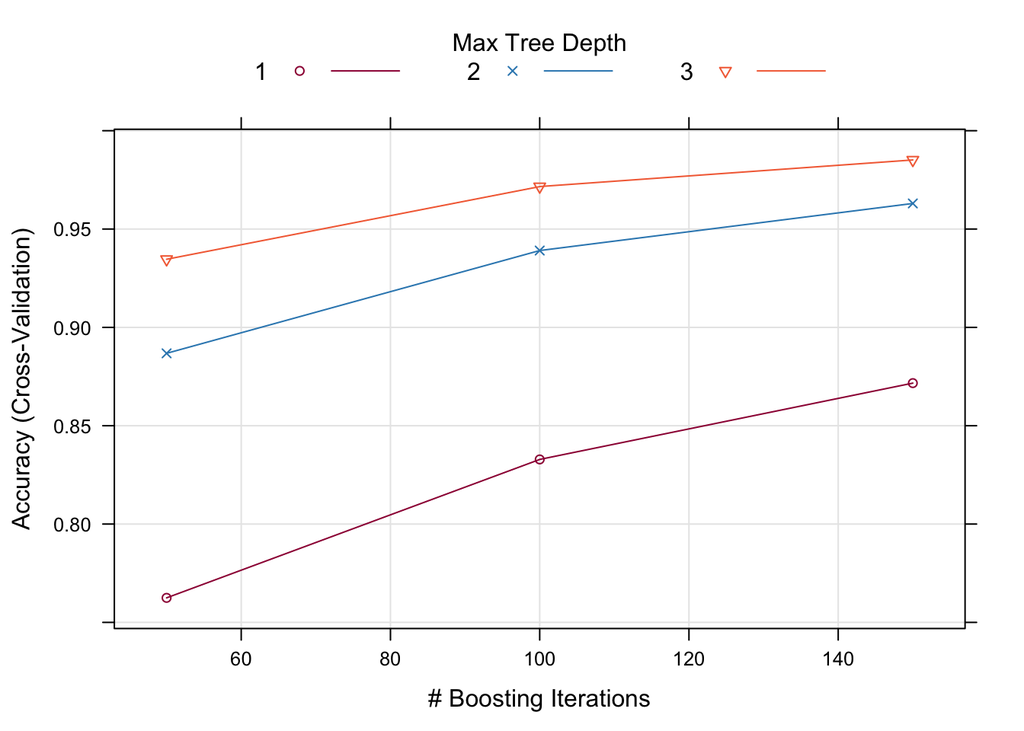

```r
# Testing the model.
pred_gbm <- predict(mod_gbm, validation)
CM_gbm <- confusionMatrix(pred_gbm, validation$classe) #statistics to see accuracy of model

trellis.par.set(caretTheme())
plot(mod_gbm)
```

[figure not shown]

```r
# Plot the model
plot(CM_gbm$table, col = CM_gbm$byClass,
    main = paste("Decision Tree - Accuracy =", round(CM_gbm$overall['Accuracy'], 4)))
```

### Comparing the three alogrithms.

```r
CM_ct$overall['Accuracy']
```

```
##  Accuracy
## 0.5728122
```

```r
CM_rf$overall['Accuracy']
```

```
## Accuracy
## 0.997791
```

```r
CM_gbm$overall['Accuracy']
```

```
##  Accuracy
## 0.9877655
```

### Comparing the three alogrithms out of sample error.

```r
# Classification Tree Out of Sample Error
1 - CM_ct$overall['Accuracy']
```

```
##  Accuracy
## 0.4271878
```

```r
# Random Out of Sample Error
1 - CM_rf$overall['Accuracy']
```

```
##    Accuracy
## 0.002209006
```

```r
# Boosting Out of Sample Error
1 - CM_gbm$overall['Accuracy']
```

```
##   Accuracy
## 0.01223449
```

### Testing best model

```r
results <- predict(mod_rf, testing)
results
```

```
##  [1] B A B A A E D B A A B C B A E E A B B B
## Levels: A B C D E
```